# EDA Code Notebook

## Visualizing the Distribution

### Plots Comparing Men and Women Across Race/Ethnic Groups

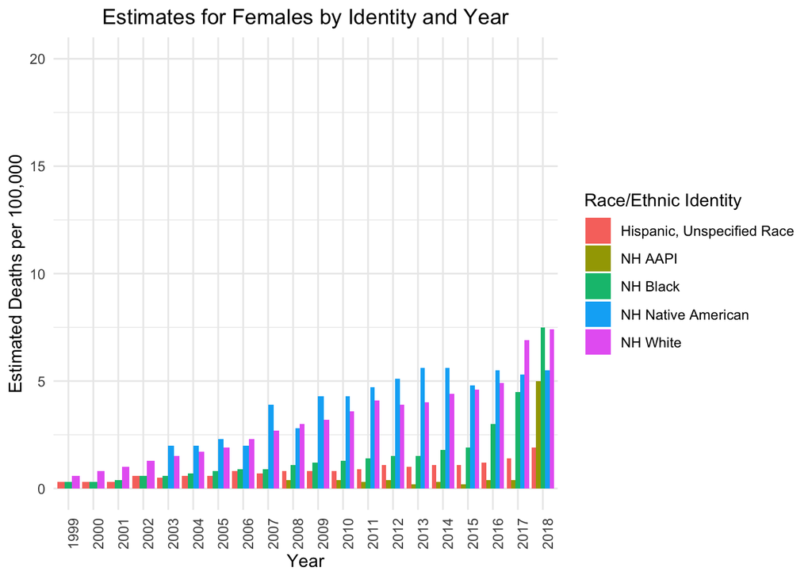

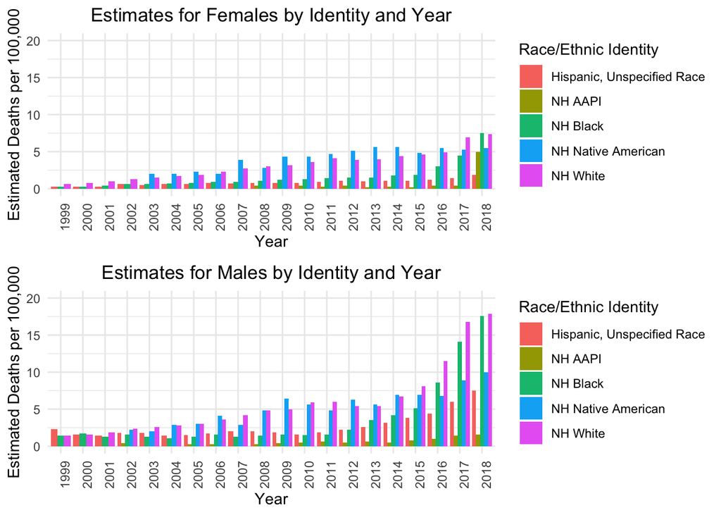

#### These data tell us a lot regarding the different observations witnessed. It is important to look at the distribution because it provide us with essential information about certain sex/race pairings, as well as the general trends of these groups over time. Such information is helpful as we perform more “narrow” visualizations and analysis.

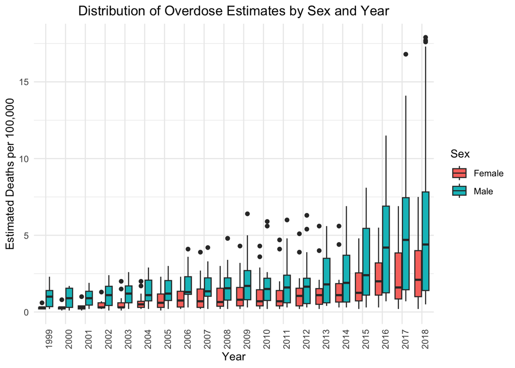

```r
## To visualize our data, we first looked at the distribution of Race_Sex by the estimate, to see which race and gender had the highest rate of drug overdose.


## The median lines of each box plot imply that among all drug types and across the 20 year period of the data, Native American Males and White Males have the highest rates of death from overdose. It appears that White Males and Black Males have the highest variation as it relates to drug overdoses. We can verify these findings in the next section where we analyze the central tendencies of the data.


## The next variable we looked at is the YEAR to showcase the distribution of how the number of overdose has changed over time. Instead of focusing on both the race and sex, we found it would be beneficial to just focus sex as the graph might be over saturated.

year_Sex <- ggplot(drug_RES, aes(x = factor(YEAR), y = ESTIMATE, fill = Sex)) +
  geom_boxplot(na.rm = TRUE) +
  labs(title = "Distribution of Overdose Estimates by Sex and Year",
       x = "Year",
       y = "Estimated Deaths per 100,000") +
  theme_minimal() + theme(axis.text.x = element_text(angle = 90)) + theme(plot.title = element_text(hjust = 0.5))

year_Sex
```

[output not shown]

[output not shown]

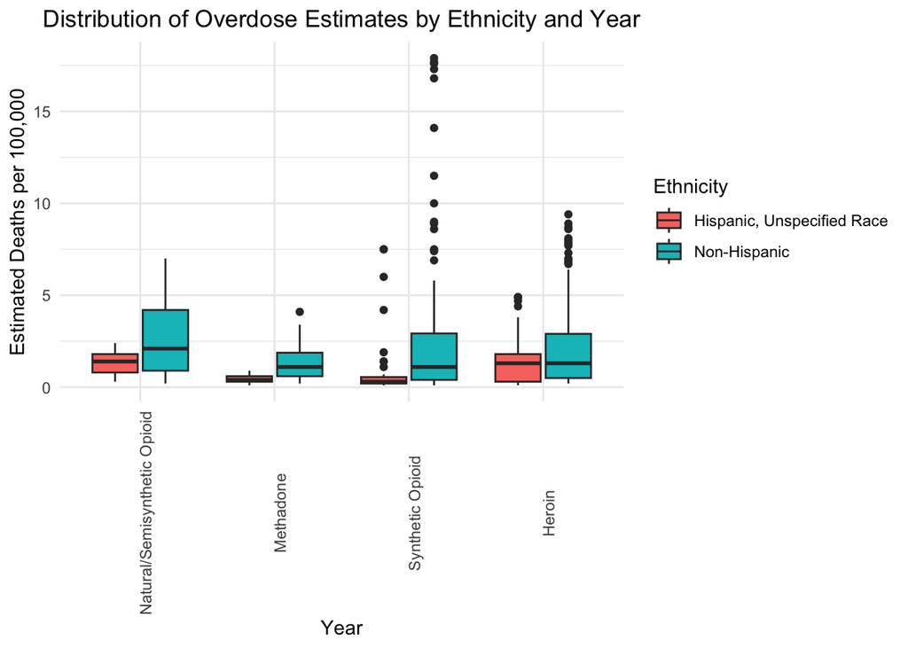

```r
year_Ethnicity <- ggplot(drug_RES, aes(x = factor(Responsible_Drug), y = ESTIMATE, fill = Ethnicity)) +
  geom_boxplot(na.rm = TRUE) +
  labs(title = "Distribution of Overdose Estimates by Ethnicity and Year",
       x = "Year",
       y = "Estimated Deaths per 100,000") +
  theme_minimal() + theme(axis.text.x = element_text(angle = 90)) + theme(plot.title = element_text(hjust = 0.5))

year_Ethnicity
```

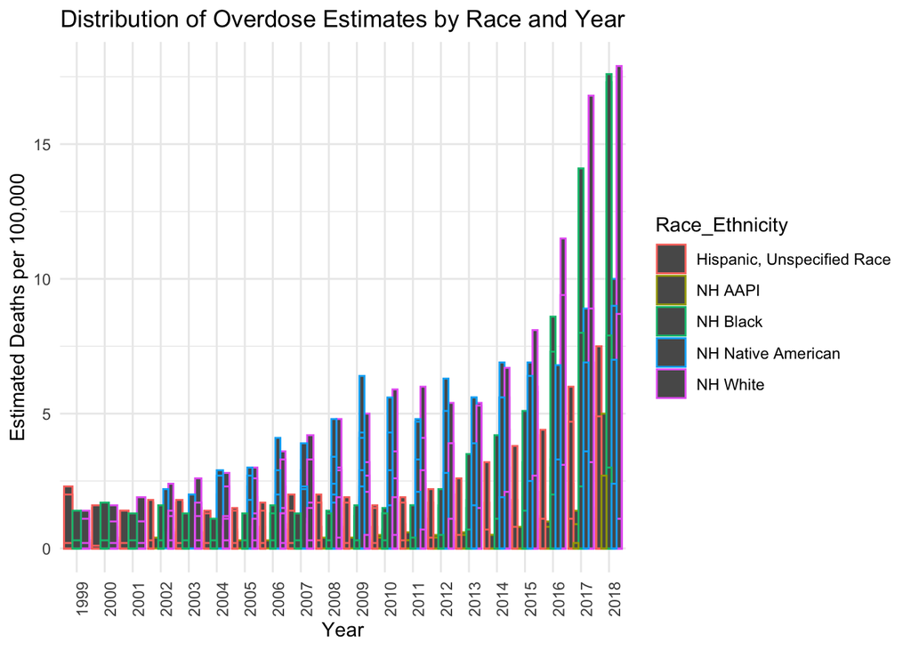

```r
year_Race <- ggplot(drug_RES, aes(x = factor(YEAR), y = ESTIMATE, color = Race_Ethnicity)) +
  labs(title = "Distribution of Overdose Estimates by Race and Year",
       x = "Year",
       y = "Estimated Deaths per 100,000") +
  theme_minimal() + theme(axis.text.x = element_text(angle = 90)) + theme(plot.title = element_text(hjust = 0.5)) +   geom_bar(stat = "identity", position = "dodge")

year_Race
```

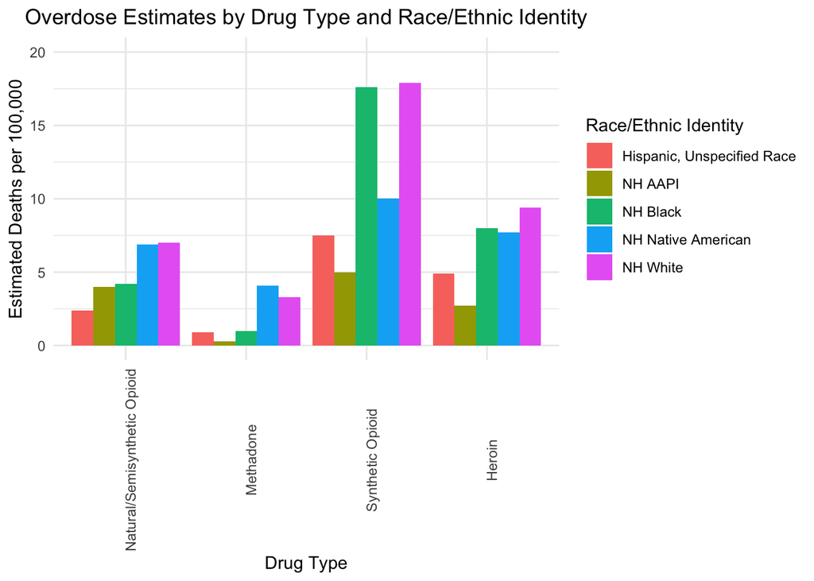

```r
## The graph shows that a common trend for both female and male is that as the year increased the number of drug overdose increased. While it was a subtle increase for females, the males saw a larger rise in drug overdose deaths. The differences in the rate of increase are visible from the continued distance in the median bar between females and males as time goes on. Again, we can verify this with additional central tendency measures.


## Finally, we wanted to see the distribution of the different drug type overdose among the different race and genders to see which type is more prevalent.

type_RE <- ggplot(drug_RES, aes(x = factor(Responsible_Drug), y = ESTIMATE, fill = Race_Ethnicity)) +
  geom_bar(stat = "identity", position = "dodge",na.rm = TRUE) +
  labs(title = "Overdose Estimates by Drug Type and Race/Ethnic Identity",
       x = "Drug Type",
       y = "Estimated Deaths per 100,000") +
  theme_minimal() + theme(axis.text.x = element_text(angle = 90)) + labs(fill = "Race/Ethnic Identity") + theme(plot.title = element_text(hjust = 0.5)) + ylim(0,20)

type_RE
```

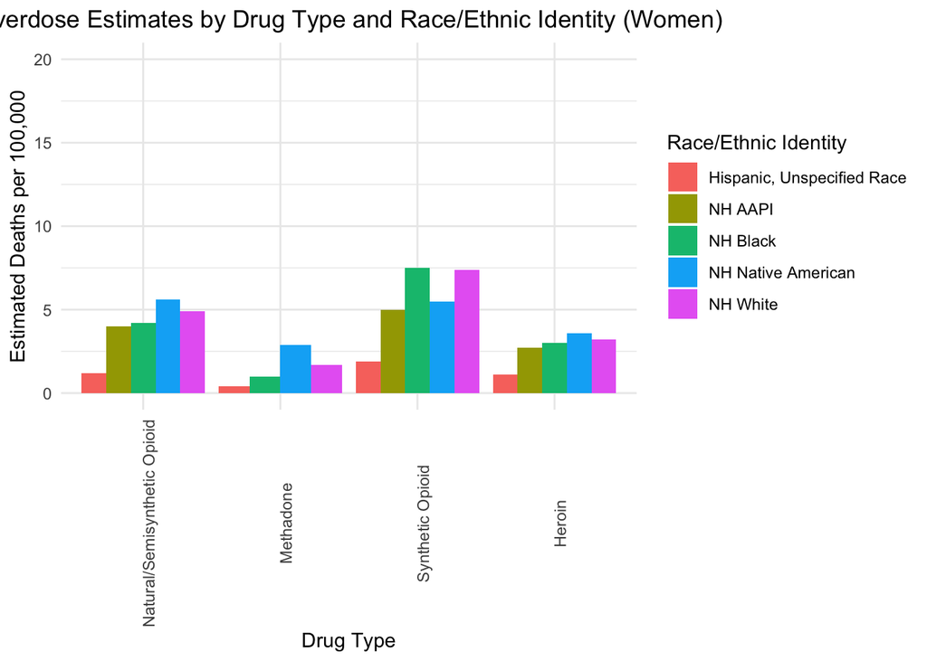

```r
type_REF <- ggplot(drug_Fem, aes(x = factor(Responsible_Drug), y = ESTIMATE, fill = Race_Ethnicity)) +
  geom_bar(stat = "identity", position = "dodge",na.rm = TRUE) +
  labs(title = "Overdose Estimates by Drug Type and Race/Ethnic Identity (Women)",
       x = "Drug Type",
       y = "Estimated Deaths per 100,000") +
  theme_minimal() + theme(axis.text.x = element_text(angle = 90)) + labs(fill = "Race/Ethnic Identity") + theme(plot.title = element_text(hjust = 0.5)) + ylim(0, 20)



type_REM <- ggplot(drug_Male, aes(x = factor(Responsible_Drug), y = ESTIMATE, fill = Race_Ethnicity))+
  geom_bar(stat = "identity", position = "dodge",na.rm = TRUE) +
  labs(title = "Overdose Estimates by Drug Type and Race/Ethnic Identity (Men)",
       x = "Drug Type",
       y = "Estimated Deaths per 100,000") +
  theme_minimal() + theme(axis.text.x = element_text(angle = 90)) + labs(fill = "Race/Ethnic Identity") + theme(plot.title = element_text(hjust = 0.5)) + ylim(0, 20)

type_REF
```

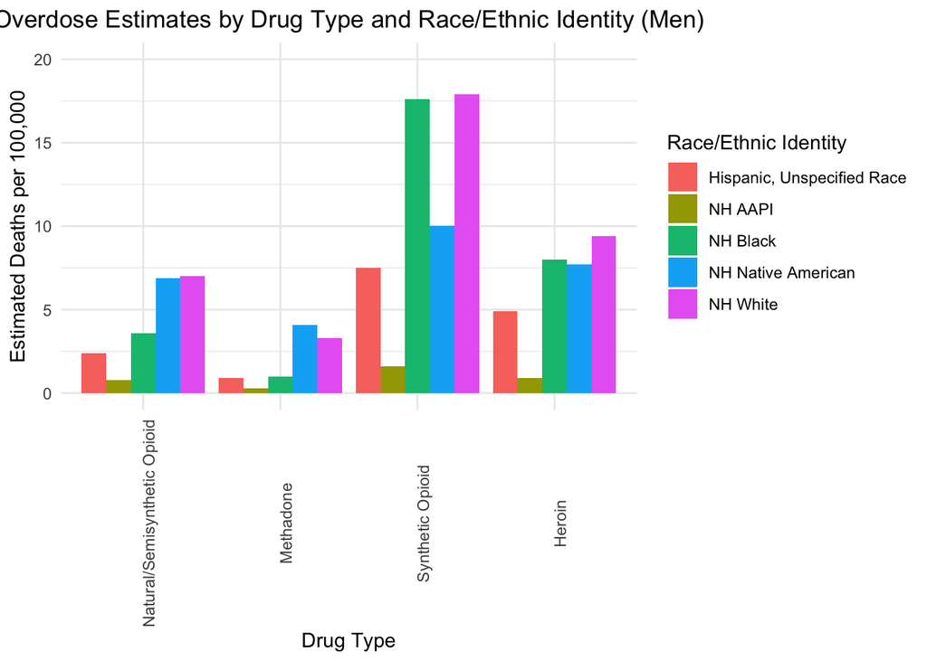

```r
type_REM
```